# Programming CDISC ADaM ADNCA using R and `{admiral}`

PHUSE US Connect 2023

Jeff Dickinson, Navitas Data Sciences

## Agenda

- Basic Concepts of Non-Compartmental Analysis NCA
- Quick overview of `{admiral}`
- Coding Steps for ADNCA
- New Functionality Highlights
- Conclusions
- Questions and Answers

## CDISC Standards for Non-Compartmental Analysis

[figure not shown]

https://www.cdisc.org/standards/foundational/adam/adamig-non-compartmental-analysis-input-data-v1-0

## Non-Compartmental Analysis (NCA)

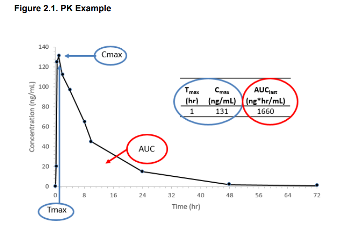

Example PK Curve with Parameters

## Important Components of ADNCA datasets

- Inclusion of Both PK Concentration records `PC` and Dosing Records `EX`
- Timing Variables for Nominal and Actual Time
- Duplicated Records for Analysis
- Exclusion Flags

Note: I will be using terms `ADNCA` and `ADPC` interchangeably

## Time Variables

| Variable | Variable Label |
| --- | --- |
| NFRLT | Nom. Rel. Time from Analyte First Dose |
| AFRLT | Act. Rel. Time from Analyte First Dose |
| NRRLT | Nominal Rel. Time from Ref. Dose |
| ARRLT | Actual Rel. Time from Ref. Dose |
| MRRLT | Modified Rel. Time from Ref. Dose |

Note: a relative time variable may refer to previous dose or next dose

## Duplicated Records for Analysis

- Use One Record in More than One Way
- Record may be both “24 Hour Post-Dose” and “Pre-Dose”
- Or “Cycle 2 Day 1 Pre-Dose” and “Cycle 1 Day 28 Post-Dose”
- Relative Times for “Pre-Dose” will be Negative
- Create `DTYPE` = “COPY” Records
- Original `PCSEQ` is Retained

## Brief Overview of `{admiral}`

[figure not shown]

https://github.com/pharmaverse/admiral

## `{admiral}`

- `AD`a`M i`n `R A`sset `L`ibrary
- `{admiral}` is Open Source and Collaborative
- `{admiral}` is Modular
- `{admiral}` is Part of Pharmaverse

## `{admiral}` is Open Source and Collaborative

[figure not shown]

{admiral} Ecosystem

## `{admiral}` is Modular

- Not One Large Function (e.g. `create_adpc()`)
- Multiple Coordinated Functions

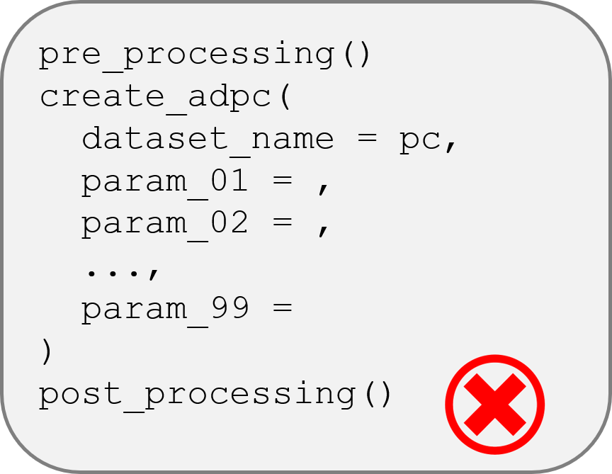

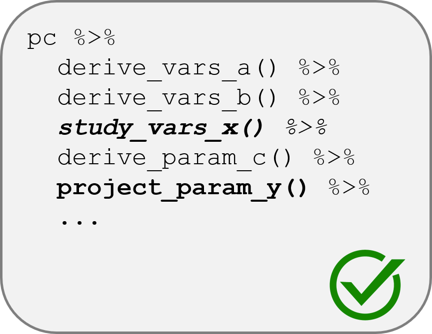

## `{admiral}` is Part of Pharmaverse

[figure not shown]

https://github.com/pharmaverse

## `{admiral}` updates for PK

(March 6, 2023 release 0.10.0)

- New `ad_adpc.R` Template
- New PK Programming Vignette
- Updates to `create_single_dose_dataset()` function

## Programming Workflow

- Read in Data
- Expand Dosing Records
- Find First Dose and Calculate First Datetime
- Find Reference Dose Dates Corresponding to PK Records
- Combine `PC` and `EX` Records and Derive Relative Time Variables
- Derive Analysis Variables

## Programming Workflow (Continued)

- Create Duplicated Records for Analysis
- Combine `ADPC` data with Duplicated Records
- Calculate Baseline and Change from Baseline
- Assign `ASEQ`
- Add Additional Baseline Variables
- Add ADSL variables
- Add Labels and Attributes

## `{admiral}` Libraries

```r
library(admiral)
library(admiraldev)
library(pharmaversesdtm)
library(dplyr)
library(lubridate)
library(stringr)
```

## Read in Data

```r
data("admiral_adsl")
data("ex")
data("pc")
data("vs")

adsl <- admiral_adsl
ex <- convert_blanks_to_na(ex)
pc <- convert_blanks_to_na(pc)
vs <- convert_blanks_to_na(vs)
```

## `PC` Rawdata

```
# A tibble: 14 × 6
   USUBJID     PCTEST     PCDTC               VISIT    PCTPT            PCSTRESN
   <chr>       <chr>      <chr>               <chr>    <chr>               <dbl>
 1 01-701-1028 XANOMELINE 2013-07-18T23:30:00 BASELINE Pre-dose           0
 2 01-701-1028 XANOMELINE 2013-07-19T00:05:00 BASELINE 5 Min Post-dose    0.102
 3 01-701-1028 XANOMELINE 2013-07-19T00:30:00 BASELINE 30 Min Post-dose   0.547
 4 01-701-1028 XANOMELINE 2013-07-19T01:00:00 BASELINE 1h Post-dose       0.925
 5 01-701-1028 XANOMELINE 2013-07-19T01:30:00 BASELINE 1.5h Post-dose     1.19
 6 01-701-1028 XANOMELINE 2013-07-19T02:00:00 BASELINE 2h Post-dose       1.37
 7 01-701-1028 XANOMELINE 2013-07-19T04:00:00 BASELINE 4h Post-dose       1.68
 8 01-701-1028 XANOMELINE 2013-07-19T06:00:00 BASELINE 6h Post-dose       1.76
 9 01-701-1028 XANOMELINE 2013-07-19T08:00:00 BASELINE 8h Post-dose       1.77
10 01-701-1028 XANOMELINE 2013-07-19T12:00:00 BASELINE 12h Post-dose      0.495
11 01-701-1028 XANOMELINE 2013-07-19T16:00:00 BASELINE 16h Post-dose      0.138
12 01-701-1028 XANOMELINE 2013-07-20T00:00:00 BASELINE 24h Post-dose      0.0107
13 01-701-1028 XANOMELINE 2013-07-20T12:00:00 BASELINE 36h Post-dose     NA
14 01-701-1028 XANOMELINE 2013-07-21T00:00:00 BASELINE 48h Post-dose     NA
```

This CDISC test `PC` data has concentrations over 48 hours from a daily patch

## Join `ADSL` with `PC`

- Use function `derive_vars_merged()`
- Convert Dates to Numeric
- Functions
  - `derive_vars_dtm()`
  - `derive_vars_dtm_to_dt()`
  - `derive_vars_dtm_to_tm()`
  - `derive_vars_dy()`
- Derive `NFRLT` for `PC` data based on `PCTPTNUM`

## `PC` Merge Code

```r
adsl_vars <- exprs(TRTSDT, TRTSDTM, TRT01P, TRT01A)

adpc <- pc %>%
  # Join ADSL with PC (need TRTSDT for ADY derivation)
  derive_vars_merged(
    dataset_add = adsl,
    new_vars = adsl_vars,
    by_vars = exprs(STUDYID, USUBJID)
  ) %>%
  # Calculate ADTM, ADT, ADY
  derive_vars_dtm(
    new_vars_prefix = "A",
    dtc = PCDTC,
    time_imputation = "00:00:00"
  ) %>%
  # Derive dates and times from date/times
  derive_vars_dtm_to_dt(exprs(ADTM)) %>%
  derive_vars_dtm_to_tm(exprs(ADTM)) %>%
  derive_vars_dy(reference_date = TRTSDT, source_vars = exprs(ADT)) %>%
  # Derive event ID and nominal relative time from first dose (NFRLT)
  mutate(
    EVID = 0,
    DRUG = PCTEST,
    NFRLT = if_else(PCTPTNUM < 0, 0, PCTPTNUM), .after = USUBJID
  )
```

## `PC` Merge Code Output

```
# A tibble: 14 × 6
   USUBJID     PCTEST     ADTM                VISIT    PCTPT            NFRLT
   <chr>       <chr>      <dttm>              <chr>    <chr>            <dbl>
 1 01-701-1028 XANOMELINE 2013-07-18 23:30:00 BASELINE Pre-dose          0
 2 01-701-1028 XANOMELINE 2013-07-19 00:05:00 BASELINE 5 Min Post-dose   0.08
 3 01-701-1028 XANOMELINE 2013-07-19 00:30:00 BASELINE 30 Min Post-dose  0.5
 4 01-701-1028 XANOMELINE 2013-07-19 01:00:00 BASELINE 1h Post-dose      1
 5 01-701-1028 XANOMELINE 2013-07-19 01:30:00 BASELINE 1.5h Post-dose    1.5
 6 01-701-1028 XANOMELINE 2013-07-19 02:00:00 BASELINE 2h Post-dose      2
 7 01-701-1028 XANOMELINE 2013-07-19 04:00:00 BASELINE 4h Post-dose      4
 8 01-701-1028 XANOMELINE 2013-07-19 06:00:00 BASELINE 6h Post-dose      6
 9 01-701-1028 XANOMELINE 2013-07-19 08:00:00 BASELINE 8h Post-dose      8
10 01-701-1028 XANOMELINE 2013-07-19 12:00:00 BASELINE 12h Post-dose    12
11 01-701-1028 XANOMELINE 2013-07-19 16:00:00 BASELINE 16h Post-dose    16
12 01-701-1028 XANOMELINE 2013-07-20 00:00:00 BASELINE 24h Post-dose    24
13 01-701-1028 XANOMELINE 2013-07-20 12:00:00 BASELINE 36h Post-dose    36
14 01-701-1028 XANOMELINE 2013-07-21 00:00:00 BASELINE 48h Post-dose    48
```

Note numeric datetimes and Nominal Relative Time from Analyte First Dose (`NFRLT`)

## `EX` Rawdata

```
# A tibble: 3 × 7
  USUBJID     EXTRT      EXDOSFRQ EXSTDTC    EXENDTC    VISIT    VISITDY
  <chr>       <chr>      <chr>    <chr>      <chr>      <chr>      <dbl>
1 01-701-1028 XANOMELINE QD       2013-07-19 2013-08-01 BASELINE       1
2 01-701-1028 XANOMELINE QD       2013-08-02 2014-01-06 WEEK 2        14
3 01-701-1028 XANOMELINE QD       2014-01-07 2014-01-14 WEEK 24      168
```

This CDISC test exposure data is for a daily patch

## Merge `ADSL` with `EX`

- Use Function `derive_vars_merged()`
- Keep Only Non-Zero Dose
- Convert Dates to Numeric
- Impute missing times to 0:00*
- Functions
  - `derive_vars_dtm()`
  - `derive_vars_dtm_to_dt()`
- Derive `NFRLT` based on `VISITDY`

## `EX` Merge Code

```r
#|
# ---- Get dosing information ----

ex <- ex %>%
  derive_vars_merged(
    dataset_add = adsl,
    new_vars = adsl_vars,
    by_vars = exprs(STUDYID, USUBJID)
  ) %>%
  # Keep records with nonzero dose
  filter(EXDOSE > 0) %>%
  # Add time and set missing end date to start date
  # Impute missing time to 00:00:00
  # Derive Analysis Start and End Dates
  derive_vars_dtm(
    new_vars_prefix = "AST",
    dtc = EXSTDTC,
    time_imputation = "00:00:00"
  ) %>%
  derive_vars_dtm(
    new_vars_prefix = "AEN",
    dtc = EXENDTC,
    time_imputation = "00:00:00"
  ) %>%
  # Derive event ID and nominal relative time from first dose (NFRLT)
  mutate(
    EVID = 1,
    NFRLT = 24 * (VISITDY - 1), .after = USUBJID
  ) %>%
  # Set missing end dates to start date
  mutate(AENDTM = case_when(
    is.na(AENDTM) ~ ASTDTM,
    TRUE ~ AENDTM
  )) %>%
  # Derive dates from date/times
  derive_vars_dtm_to_dt(exprs(ASTDTM)) %>%
  derive_vars_dtm_to_dt(exprs(AENDTM))
```

## `EX` Merge Output

```
# A tibble: 3 × 7
  USUBJID     EXTRT      EXDOSFRQ ASTDT      AENDT      VISITDY NFRLT
  <chr>       <chr>      <chr>    <date>     <date>       <dbl> <dbl>
1 01-701-1028 XANOMELINE QD       2013-07-19 2013-08-01       1     0
2 01-701-1028 XANOMELINE QD       2013-08-02 2014-01-06      14   312
3 01-701-1028 XANOMELINE QD       2014-01-07 2014-01-14     168  4008
```

Note numeric dates and Nominal Relative Time from Analyte First Dose (`NFRLT`)

## Expand Dosing Records

- Need to add records between start date and end date
- Use function `create_single_dose_dataset()`
- Need to also expand nominal relative time `NFRLT`
- For example `EXDOSFRQ` = “QD” will expand `NFRLT` by 24 hours
- New feature of function

## Expansion Example Code

```r
# ---- Expand dosing records between start and end dates ----

ex_exp <- ex %>%
  create_single_dose_dataset(
    dose_freq = EXDOSFRQ,
    start_date = ASTDT,
    start_datetime = ASTDTM,
    end_date = AENDT,
    end_datetime = AENDTM,
    nominal_time = NFRLT,
    lookup_table = dose_freq_lookup,
    lookup_column = CDISC_VALUE,
    keep_source_vars = exprs(
      STUDYID, USUBJID, EVID, EXDOSFRQ, EXDOSFRM,
      NFRLT, EXDOSE, EXDOSU, EXTRT, ASTDT, ASTDTM, AENDT, AENDTM,
      VISIT, VISITNUM, VISITDY,
      TRT01A, TRT01P, DOMAIN, EXSEQ, !!!adsl_vars
    )
  ) %>%
  # Derive AVISIT based on nominal relative time
  mutate(
    AVISITN = NFRLT %/% 24 + 1,
    AVISIT = paste("Day", AVISITN),
    ADTM = ASTDTM,
    DRUG = EXTRT,
  ) %>%
  # Derive dates and times from datetimes
  derive_vars_dtm_to_dt(exprs(ADTM)) %>%
  derive_vars_dtm_to_tm(exprs(ADTM)) %>%
  derive_vars_dtm_to_tm(exprs(ASTDTM)) %>%
  derive_vars_dtm_to_tm(exprs(AENDTM)) %>%
  derive_vars_dy(reference_date = TRTSDT, source_vars = exprs(ADT))
```

## Expansion Code Output

```
# A tibble: 20 × 6
   USUBJID     DRUG       EXDOSFRQ ASTDT      AVISIT NFRLT
   <chr>       <chr>      <chr>    <date>     <chr>  <dbl>
 1 01-701-1028 XANOMELINE ONCE     2013-07-19 Day 1      0
 2 01-701-1028 XANOMELINE ONCE     2013-07-20 Day 2     24
 3 01-701-1028 XANOMELINE ONCE     2013-07-21 Day 3     48
 4 01-701-1028 XANOMELINE ONCE     2013-07-22 Day 4     72
 5 01-701-1028 XANOMELINE ONCE     2013-07-23 Day 5     96
 6 01-701-1028 XANOMELINE ONCE     2013-07-24 Day 6    120
 7 01-701-1028 XANOMELINE ONCE     2013-07-25 Day 7    144
 8 01-701-1028 XANOMELINE ONCE     2013-07-26 Day 8    168
 9 01-701-1028 XANOMELINE ONCE     2013-07-27 Day 9    192
10 01-701-1028 XANOMELINE ONCE     2013-07-28 Day 10   216
11 01-701-1028 XANOMELINE ONCE     2013-07-29 Day 11   240
12 01-701-1028 XANOMELINE ONCE     2013-07-30 Day 12   264
13 01-701-1028 XANOMELINE ONCE     2013-07-31 Day 13   288
14 01-701-1028 XANOMELINE ONCE     2013-08-01 Day 14   312
15 01-701-1028 XANOMELINE ONCE     2013-08-02 Day 14   312
16 01-701-1028 XANOMELINE ONCE     2013-08-03 Day 15   336
17 01-701-1028 XANOMELINE ONCE     2013-08-04 Day 16   360
18 01-701-1028 XANOMELINE ONCE     2013-08-05 Day 17   384
19 01-701-1028 XANOMELINE ONCE     2013-08-06 Day 18   408
20 01-701-1028 XANOMELINE ONCE     2013-08-07 Day 19   432
```

Note: `NFRLT` is expanded by 24 hours for each record `AVISIT` has values “Day 1”, “Day 2”, “Day 3”, etc.

## Find First Dose and Calculate `FANLDTM`

- Use Function `derive_vars_merged()`
- Parameter `new_vars` used to derive `FANLDTM`
- Recalculate `AVISIT` and `AVISITN` based on `NFRLT` for this study

`FANLDTM` = First Datetime of Dose for Analyte

## First Dose Code

```r
# ---- Find first dose per treatment per subject ----
# ---- Join with ADPC data and keep only subjects with dosing ----

adpc <- adpc %>%
  derive_vars_merged(
    dataset_add = ex_exp,
    filter_add = (EXDOSE > 0 & !is.na(ADTM)),
    new_vars = exprs(FANLDTM = ADTM),
    order = exprs(ADTM, EXSEQ),
    mode = "first",
    by_vars = exprs(STUDYID, USUBJID, DRUG)
  ) %>%
  filter(!is.na(FANLDTM)) %>%
  # Derive AVISIT from nominal relative time
  mutate(
    AVISITN = NFRLT %/% 24 + 1,
    AVISIT = paste("Day", AVISITN),
  )
```

## First Dose Output

```
# A tibble: 14 × 5
   USUBJID     FANLDTM             AVISIT ADTM                PCTPT
   <chr>       <dttm>              <chr>  <dttm>              <chr>
 1 01-701-1028 2013-07-19 00:00:00 Day 1  2013-07-18 23:30:00 Pre-dose
 2 01-701-1028 2013-07-19 00:00:00 Day 1  2013-07-19 00:05:00 5 Min Post-dose
 3 01-701-1028 2013-07-19 00:00:00 Day 1  2013-07-19 00:30:00 30 Min Post-dose
 4 01-701-1028 2013-07-19 00:00:00 Day 1  2013-07-19 01:00:00 1h Post-dose
 5 01-701-1028 2013-07-19 00:00:00 Day 1  2013-07-19 01:30:00 1.5h Post-dose
 6 01-701-1028 2013-07-19 00:00:00 Day 1  2013-07-19 02:00:00 2h Post-dose
 7 01-701-1028 2013-07-19 00:00:00 Day 1  2013-07-19 04:00:00 4h Post-dose
 8 01-701-1028 2013-07-19 00:00:00 Day 1  2013-07-19 06:00:00 6h Post-dose
 9 01-701-1028 2013-07-19 00:00:00 Day 1  2013-07-19 08:00:00 8h Post-dose
10 01-701-1028 2013-07-19 00:00:00 Day 1  2013-07-19 12:00:00 12h Post-dose
11 01-701-1028 2013-07-19 00:00:00 Day 1  2013-07-19 16:00:00 16h Post-dose
12 01-701-1028 2013-07-19 00:00:00 Day 2  2013-07-20 00:00:00 24h Post-dose
13 01-701-1028 2013-07-19 00:00:00 Day 2  2013-07-20 12:00:00 36h Post-dose
14 01-701-1028 2013-07-19 00:00:00 Day 3  2013-07-21 00:00:00 48h Post-dose
```

`FANLDTM` = First Datetime of Dose for Analyte

## Find Reference Dose Dates Corresponding to PK Records

- Use Function `derive_vars_joined()`
- Parameter `filter_join` used to set condition

## Find Reference Dose Dates Code

```r
# ---- Find previous dose  ----
# Use derive_vars_joined() for consistency with other variables
# This is equivalent to derive_vars_last_dose() in this case

adpc <- adpc %>%
  derive_vars_joined(
    dataset_add = ex_exp,
    by_vars = exprs(USUBJID),
    order = exprs(ADTM),
    new_vars = exprs(
      ADTM_prev = ADTM, EXDOSE_prev = EXDOSE, AVISIT_prev = AVISIT,
      AENDTM_prev = AENDTM
    ),
    join_vars = exprs(ADTM),
    join_type = "all",
    filter_add = NULL,
    filter_join = ADTM > ADTM.join,
    mode = "last",
    check_type = "none"
  )
```

## Find Reference Dose Dates Output

```
# A tibble: 14 × 6
   USUBJID     VISIT   ADTM                PCTPT ADTM_prev           AVISIT_prev
   <chr>       <chr>   <dttm>              <chr> <dttm>              <chr>
 1 01-701-1028 BASELI… 2013-07-18 23:30:00 Pre-… NA                  <NA>
 2 01-701-1028 BASELI… 2013-07-19 00:05:00 5 Mi… 2013-07-19 00:00:00 Day 1
 3 01-701-1028 BASELI… 2013-07-19 00:30:00 30 M… 2013-07-19 00:00:00 Day 1
 4 01-701-1028 BASELI… 2013-07-19 01:00:00 1h P… 2013-07-19 00:00:00 Day 1
 5 01-701-1028 BASELI… 2013-07-19 01:30:00 1.5h… 2013-07-19 00:00:00 Day 1
 6 01-701-1028 BASELI… 2013-07-19 02:00:00 2h P… 2013-07-19 00:00:00 Day 1
 7 01-701-1028 BASELI… 2013-07-19 04:00:00 4h P… 2013-07-19 00:00:00 Day 1
 8 01-701-1028 BASELI… 2013-07-19 06:00:00 6h P… 2013-07-19 00:00:00 Day 1
 9 01-701-1028 BASELI… 2013-07-19 08:00:00 8h P… 2013-07-19 00:00:00 Day 1
10 01-701-1028 BASELI… 2013-07-19 12:00:00 12h … 2013-07-19 00:00:00 Day 1
11 01-701-1028 BASELI… 2013-07-19 16:00:00 16h … 2013-07-19 00:00:00 Day 1
12 01-701-1028 BASELI… 2013-07-20 00:00:00 24h … 2013-07-19 00:00:00 Day 1
13 01-701-1028 BASELI… 2013-07-20 12:00:00 36h … 2013-07-20 00:00:00 Day 2
14 01-701-1028 BASELI… 2013-07-21 00:00:00 48h … 2013-07-20 00:00:00 Day 2
```

`ADTM_prev` is the datetime of the previous dose `AVISIT_prev` is the analysis visit of the previous dose

## Find Next Dose

```r
# ---- Find next dose  ----

adpc <- adpc %>%
  derive_vars_joined(
    dataset_add = ex_exp,
    by_vars = exprs(USUBJID),
    order = exprs(ADTM),
    new_vars = exprs(
      ADTM_next = ADTM, EXDOSE_next = EXDOSE, AVISIT_next = AVISIT,
      AENDTM_next = AENDTM
    ),
    join_vars = exprs(ADTM),
    join_type = "all",
    filter_add = NULL,
    filter_join = ADTM <= ADTM.join,
    mode = "first",
    check_type = "none"
  )
```

## Find Next Dose Output

```
# A tibble: 14 × 6
   USUBJID     VISIT   ADTM                PCTPT ADTM_next           AVISIT_next
   <chr>       <chr>   <dttm>              <chr> <dttm>              <chr>
 1 01-701-1028 BASELI… 2013-07-18 23:30:00 Pre-… 2013-07-19 00:00:00 Day 1
 2 01-701-1028 BASELI… 2013-07-19 00:05:00 5 Mi… 2013-07-20 00:00:00 Day 2
 3 01-701-1028 BASELI… 2013-07-19 00:30:00 30 M… 2013-07-20 00:00:00 Day 2
 4 01-701-1028 BASELI… 2013-07-19 01:00:00 1h P… 2013-07-20 00:00:00 Day 2
 5 01-701-1028 BASELI… 2013-07-19 01:30:00 1.5h… 2013-07-20 00:00:00 Day 2
 6 01-701-1028 BASELI… 2013-07-19 02:00:00 2h P… 2013-07-20 00:00:00 Day 2
 7 01-701-1028 BASELI… 2013-07-19 04:00:00 4h P… 2013-07-20 00:00:00 Day 2
 8 01-701-1028 BASELI… 2013-07-19 06:00:00 6h P… 2013-07-20 00:00:00 Day 2
 9 01-701-1028 BASELI… 2013-07-19 08:00:00 8h P… 2013-07-20 00:00:00 Day 2
10 01-701-1028 BASELI… 2013-07-19 12:00:00 12h … 2013-07-20 00:00:00 Day 2
11 01-701-1028 BASELI… 2013-07-19 16:00:00 16h … 2013-07-20 00:00:00 Day 2
12 01-701-1028 BASELI… 2013-07-20 00:00:00 24h … 2013-07-20 00:00:00 Day 2
13 01-701-1028 BASELI… 2013-07-20 12:00:00 36h … 2013-07-21 00:00:00 Day 3
14 01-701-1028 BASELI… 2013-07-21 00:00:00 48h … 2013-07-21 00:00:00 Day 3
```

`ADTM_next` is the datetime of the next dose

## Find Previous Nominal Dose

```r
# ---- Find previous nominal time ----

adpc <- adpc %>%
  derive_vars_joined(
    dataset_add = ex_exp,
    by_vars = exprs(USUBJID),
    order = exprs(NFRLT),
    new_vars = exprs(NFRLT_prev = NFRLT),
    join_vars = exprs(NFRLT),
    join_type = "all",
    filter_add = NULL,
    filter_join = NFRLT > NFRLT.join,
    mode = "last",
    check_type = "none"
  )
```

## Find Next Nominal Dose

```r
# ---- Find next nominal time ----

adpc <- adpc %>%
  derive_vars_joined(
    dataset_add = ex_exp,
    by_vars = exprs(USUBJID),
    order = exprs(NFRLT),
    new_vars = exprs(NFRLT_next = NFRLT),
    join_vars = exprs(NFRLT),
    join_type = "all",
    filter_add = NULL,
    filter_join = NFRLT <= NFRLT.join,
    mode = "first",
    check_type = "none"
  )
```

## Find Next Nominal Dose Output

```
# A tibble: 14 × 5
   USUBJID     NFRLT PCTPT            NFRLT_prev NFRLT_next
   <chr>       <dbl> <chr>                 <dbl>      <dbl>
 1 01-701-1028  0    Pre-dose                 NA          0
 2 01-701-1028  0.08 5 Min Post-dose           0         24
 3 01-701-1028  0.5  30 Min Post-dose          0         24
 4 01-701-1028  1    1h Post-dose              0         24
 5 01-701-1028  1.5  1.5h Post-dose            0         24
 6 01-701-1028  2    2h Post-dose              0         24
 7 01-701-1028  4    4h Post-dose              0         24
 8 01-701-1028  6    6h Post-dose              0         24
 9 01-701-1028  8    8h Post-dose              0         24
10 01-701-1028 12    12h Post-dose             0         24
11 01-701-1028 16    16h Post-dose             0         24
12 01-701-1028 24    24h Post-dose             0         24
13 01-701-1028 36    36h Post-dose            24         48
14 01-701-1028 48    48h Post-dose            24         48
```

`NFRLT_prev` is the nominal relative time from the previous dose `NFRLT_next` is the nominal relative time for the next dose

## Combine PC and EX Records and Derive Relative Time Variables

- Include both dosing and concentration records
- Use function `derive_vars_duration()`
- Create Actual Relative Time `AFRLT`

## Combine PC and EX Records and Derive Relative Time Variables Code

```r
# ---- Combine ADPC and EX data ----
# Derive Relative Time Variables


adpc <- bind_rows(adpc, ex_exp) %>%
  group_by(USUBJID, DRUG) %>%
  mutate(
    FANLDTM = min(FANLDTM, na.rm = TRUE),
    min_NFRLT = min(NFRLT_prev, na.rm = TRUE),
    maxdate = max(ADT[EVID == 0], na.rm = TRUE), .after = USUBJID
  ) %>%
  arrange(USUBJID, ADTM) %>%
  ungroup() %>%
  filter(ADT <= maxdate) %>%
  # Derive Actual Relative Time from First Dose (AFRLT)
  derive_vars_duration(
    new_var = AFRLT,
    start_date = FANLDTM,
    end_date = ADTM,
    out_unit = "hours",
    floor_in = FALSE,
    add_one = FALSE
  ) %>%
  # Derive Actual Relative Time from Reference Dose (ARRLT)
  derive_vars_duration(
    new_var = ARRLT,
    start_date = ADTM_prev,
    end_date = ADTM,
    out_unit = "hours",
    floor_in = FALSE,
    add_one = FALSE
  ) %>%
  # Derive Actual Relative Time from Next Dose (AXRLT not kept)
  derive_vars_duration(
    new_var = AXRLT,
    start_date = ADTM_next,
    end_date = ADTM,
    out_unit = "hours",
    floor_in = FALSE,
    add_one = FALSE
  ) %>%
  mutate(
    ARRLT = case_when(
      EVID == 1 ~ 0,
      is.na(ARRLT) ~ AXRLT,
      TRUE ~ ARRLT
    ),

    # Derive Reference Dose Date
    PCRFTDTM = case_when(
      EVID == 1 ~ ADTM,
      is.na(ADTM_prev) ~ ADTM_next,
      TRUE ~ ADTM_prev
    )
  ) %>%
  # Derive dates and times from datetimes
  derive_vars_dtm_to_dt(exprs(FANLDTM)) %>%
  derive_vars_dtm_to_tm(exprs(FANLDTM)) %>%
  derive_vars_dtm_to_dt(exprs(PCRFTDTM)) %>%
  derive_vars_dtm_to_tm(exprs(PCRFTDTM))
```

## Derive Relative Time Output

```
# A tibble: 17 × 7
   USUBJID     FANLDT     AVISIT PCTPT              AFRLT   ARRLT AXRLT
   <chr>       <date>     <chr>  <chr>              <dbl>   <dbl> <dbl>
 1 01-701-1028 2013-07-19 Day 1  Pre-dose         -0.5    -0.5     -0.5
 2 01-701-1028 2013-07-19 Day 1  <NA>              0       0       NA
 3 01-701-1028 2013-07-19 Day 1  5 Min Post-dose   0.0833  0.0833 -23.9
 4 01-701-1028 2013-07-19 Day 1  30 Min Post-dose  0.5     0.5    -23.5
 5 01-701-1028 2013-07-19 Day 1  1h Post-dose      1       1      -23
 6 01-701-1028 2013-07-19 Day 1  1.5h Post-dose    1.5     1.5    -22.5
 7 01-701-1028 2013-07-19 Day 1  2h Post-dose      2       2      -22
 8 01-701-1028 2013-07-19 Day 1  4h Post-dose      4       4      -20
 9 01-701-1028 2013-07-19 Day 1  6h Post-dose      6       6      -18
10 01-701-1028 2013-07-19 Day 1  8h Post-dose      8       8      -16
11 01-701-1028 2013-07-19 Day 1  12h Post-dose    12      12      -12
12 01-701-1028 2013-07-19 Day 1  16h Post-dose    16      16       -8
13 01-701-1028 2013-07-19 Day 2  24h Post-dose    24      24        0
14 01-701-1028 2013-07-19 Day 2  <NA>             24       0       NA
15 01-701-1028 2013-07-19 Day 2  36h Post-dose    36      12      -12
16 01-701-1028 2013-07-19 Day 3  48h Post-dose    48      24        0
17 01-701-1028 2013-07-19 Day 3  <NA>             48       0       NA
```

`AFRLT` = Actual Relative Time from Analyte First Dose `ARRLT` = Actual Relative Time from Reference Dose

## Find Nominal Relative Times

```r
adpc <- adpc %>%
  # Derive Nominal Relative Time from Reference Dose (NRRLT)
  mutate(
    NRRLT = case_when(
      EVID == 1 ~ 0,
      is.na(NFRLT_prev) ~ NFRLT - min_NFRLT,
      TRUE ~ NFRLT - NFRLT_prev
    ),
    NXRLT = case_when(
      EVID == 1 ~ 0,
      TRUE ~ NFRLT - NFRLT_next
    )
  )
```

## Nominal Relative Times Output

```
# A tibble: 17 × 6
   USUBJID     AVISIT PCTPT            NFRLT NRRLT NXRLT
   <chr>       <chr>  <chr>            <dbl> <dbl> <dbl>
 1 01-701-1028 Day 1  Pre-dose          0     0      0
 2 01-701-1028 Day 1  <NA>              0     0      0
 3 01-701-1028 Day 1  5 Min Post-dose   0.08  0.08 -23.9
 4 01-701-1028 Day 1  30 Min Post-dose  0.5   0.5  -23.5
 5 01-701-1028 Day 1  1h Post-dose      1     1    -23
 6 01-701-1028 Day 1  1.5h Post-dose    1.5   1.5  -22.5
 7 01-701-1028 Day 1  2h Post-dose      2     2    -22
 8 01-701-1028 Day 1  4h Post-dose      4     4    -20
 9 01-701-1028 Day 1  6h Post-dose      6     6    -18
10 01-701-1028 Day 1  8h Post-dose      8     8    -16
11 01-701-1028 Day 1  12h Post-dose    12    12    -12
12 01-701-1028 Day 1  16h Post-dose    16    16     -8
13 01-701-1028 Day 2  24h Post-dose    24    24      0
14 01-701-1028 Day 2  <NA>             24     0      0
15 01-701-1028 Day 2  36h Post-dose    36    12    -12
16 01-701-1028 Day 3  48h Post-dose    48    24      0
17 01-701-1028 Day 3  <NA>             48     0      0
```

`NFRLT` = Nominal Relative Time from Analyte First Dose `NRRLT` = Nominal Relative Time from Reference Dose

## Derive Analysis Variables

```r
adpc <- adpc %>%
  mutate(
    ATPTN = case_when(
      EVID == 1 ~ 0,
      TRUE ~ PCTPTNUM
    ),
    ATPT = case_when(
      EVID == 1 ~ "Dose",
      TRUE ~ PCTPT
    ),
    ATPTREF = case_when(
      EVID == 1 ~ AVISIT,
      is.na(AVISIT_prev) ~ AVISIT_next,
      TRUE ~ AVISIT_prev
    ),
    # Derive baseline flag for pre-dose records
    ABLFL = case_when(
      ATPT == "Pre-dose" ~ "Y",
      TRUE ~ NA_character_
    ),
    # Derive BASETYPE
    BASETYPE = paste(ATPTREF, "Baseline"),

    # Derive Actual Dose
    DOSEA = case_when(
      EVID == 1 ~ EXDOSE,
      is.na(EXDOSE_prev) ~ EXDOSE_next,
      TRUE ~ EXDOSE_prev
    ),
    # Derive Planned Dose
    DOSEP = case_when(
      TRT01P == "Xanomeline High Dose" ~ 81,
      TRT01P == "Xanomeline Low Dose" ~ 54
    ),
    DOSEU = "mg",
  ) %>%
  mutate(
    FRLTU = "h",
    RRLTU = "h",
    PARAMCD = coalesce(PCTESTCD, "DOSE"),
    ALLOQ = PCLLOQ,
    AVAL = case_when(
      EVID == 1 ~ EXDOSE,
      PCSTRESC == "<BLQ" & NFRLT == 0 ~ 0,
      PCSTRESC == "<BLQ" & NFRLT > 0 ~ 0.5 * ALLOQ,
      TRUE ~ PCSTRESN
    ),
    AVALU = case_when(
      EVID == 1 ~ EXDOSU,
      TRUE ~ PCSTRESU
    ),
    AVALCAT1 = if_else(PCSTRESC == "<BLQ", PCSTRESC, prettyNum(signif(AVAL, digits = 3))),
  ) %>%
  # Add SRCSEQ
  mutate(
    SRCDOM = DOMAIN,
    SRCVAR = "SEQ",
    SRCSEQ = coalesce(PCSEQ, EXSEQ)
  )
```

## Analysis Variable Output

```
# A tibble: 17 × 8
   USUBJID     NFRLT AVISIT ATPT             ABLFL ATPTREF    AVAL AVALCAT1
   <chr>       <dbl> <chr>  <chr>            <chr> <chr>     <dbl> <chr>
 1 01-701-1028  0    Day 1  Pre-dose         Y     Day 1    0      <BLQ
 2 01-701-1028  0    Day 1  Dose             <NA>  Day 1   54      <NA>
 3 01-701-1028  0.08 Day 1  5 Min Post-dose  <NA>  Day 1    0.102  0.102
 4 01-701-1028  0.5  Day 1  30 Min Post-dose <NA>  Day 1    0.547  0.547
 5 01-701-1028  1    Day 1  1h Post-dose     <NA>  Day 1    0.925  0.925
 6 01-701-1028  1.5  Day 1  1.5h Post-dose   <NA>  Day 1    1.19   1.19
 7 01-701-1028  2    Day 1  2h Post-dose     <NA>  Day 1    1.37   1.37
 8 01-701-1028  4    Day 1  4h Post-dose     <NA>  Day 1    1.68   1.68
 9 01-701-1028  6    Day 1  6h Post-dose     <NA>  Day 1    1.76   1.76
10 01-701-1028  8    Day 1  8h Post-dose     <NA>  Day 1    1.77   1.77
11 01-701-1028 12    Day 1  12h Post-dose    <NA>  Day 1    0.495  0.495
12 01-701-1028 16    Day 1  16h Post-dose    <NA>  Day 1    0.138  0.138
13 01-701-1028 24    Day 2  24h Post-dose    <NA>  Day 1    0.0107 0.0107
14 01-701-1028 24    Day 2  Dose             <NA>  Day 2   54      <NA>
15 01-701-1028 36    Day 2  36h Post-dose    <NA>  Day 2    0.005  <BLQ
16 01-701-1028 48    Day 3  48h Post-dose    <NA>  Day 2    0.005  <BLQ
17 01-701-1028 48    Day 3  Dose             <NA>  Day 3   54      <NA>
```

`ATPT` Analysis Timepoint `ATPTREF` Analysis Timepoint Reference `AVAL` Analysis Value

## Create Duplicated Records for Analysis

- Use One Record in More than One Way
- Record may be both “24 Hour Post-Dose” and “Pre-Dose”
- Create `DTYPE` = “COPY” Records
- Original `PCSEQ` is retained
- Change “24h Post-dose” to “Pre-dose”
- `ABLFL` is set to “Y”

## Duplicated Records for Analysis Code

```r
# ---- Create DTYPE copy records ----

dtype <- adpc %>%
  filter(NFRLT > 0 & NXRLT == 0 & EVID == 0 & !is.na(AVISIT_next)) %>%
  select(-PCRFTDT, -PCRFTTM) %>%
  # Re-derive variables in for DTYPE copy records
  mutate(
    ABLFL = NA_character_,
    ATPTREF = AVISIT_next,
    ARRLT = AXRLT,
    NRRLT = NXRLT,
    PCRFTDTM = ADTM_next,
    DOSEA = EXDOSE_next,
    BASETYPE = paste(AVISIT_next, "Baseline"),
    ATPT = "Pre-dose",
    ATPTN = NFRLT,
    ABLFL = "Y",
    DTYPE = "COPY"
  ) %>%
  derive_vars_dtm_to_dt(exprs(PCRFTDTM)) %>%
  derive_vars_dtm_to_tm(exprs(PCRFTDTM))
```

## Duplicated Records for Analysis Output

```
# A tibble: 2 × 8
  USUBJID     DTYPE BASETYPE       ATPT     NFRLT NRRLT AFRLT ARRLT
  <chr>       <chr> <chr>          <chr>    <dbl> <dbl> <dbl> <dbl>
1 01-701-1028 COPY  Day 2 Baseline Pre-dose    24     0    24     0
2 01-701-1028 COPY  Day 3 Baseline Pre-dose    48     0    48     0
```

Note that `NRRLT` and `ARRLT` equal zero for next dose

## Combine `ADPC` data with Duplicated Records

```r
# ---- Combine original records and DTYPE copy records ----

adpc <- bind_rows(adpc, dtype) %>%
  arrange(STUDYID, USUBJID, BASETYPE, ADTM, NFRLT) %>%
  mutate(
    # Derive MRRLT, ANL01FL and ANL02FL
    MRRLT = if_else(ARRLT < 0, 0, ARRLT),
    ANL01FL = "Y",
    ANL02FL = if_else(is.na(DTYPE), "Y", NA_character_),
  )
```

## Combine `ADPC` Output

```
# A tibble: 19 × 5
   USUBJID     BASETYPE       ATPT             DTYPE   ARRLT
   <chr>       <chr>          <chr>            <chr>   <dbl>
 1 01-701-1028 Day 1 Baseline Pre-dose         <NA>  -0.5
 2 01-701-1028 Day 1 Baseline Dose             <NA>   0
 3 01-701-1028 Day 1 Baseline 5 Min Post-dose  <NA>   0.0833
 4 01-701-1028 Day 1 Baseline 30 Min Post-dose <NA>   0.5
 5 01-701-1028 Day 1 Baseline 1h Post-dose     <NA>   1
 6 01-701-1028 Day 1 Baseline 1.5h Post-dose   <NA>   1.5
 7 01-701-1028 Day 1 Baseline 2h Post-dose     <NA>   2
 8 01-701-1028 Day 1 Baseline 4h Post-dose     <NA>   4
 9 01-701-1028 Day 1 Baseline 6h Post-dose     <NA>   6
10 01-701-1028 Day 1 Baseline 8h Post-dose     <NA>   8
11 01-701-1028 Day 1 Baseline 12h Post-dose    <NA>  12
12 01-701-1028 Day 1 Baseline 16h Post-dose    <NA>  16
13 01-701-1028 Day 1 Baseline 24h Post-dose    <NA>  24
14 01-701-1028 Day 2 Baseline Dose             <NA>   0
15 01-701-1028 Day 2 Baseline Pre-dose         COPY   0
16 01-701-1028 Day 2 Baseline 36h Post-dose    <NA>  12
17 01-701-1028 Day 2 Baseline 48h Post-dose    <NA>  24
18 01-701-1028 Day 3 Baseline Dose             <NA>   0
19 01-701-1028 Day 3 Baseline Pre-dose         COPY   0
```

## Calculate Baseline and Change from Baseline

```r
# ---- Calculate BASE and Change from Baseline ----

adpc <- adpc %>%
  # Derive BASE
  derive_var_base(
    by_vars = exprs(STUDYID, USUBJID, PARAMCD, BASETYPE),
    source_var = AVAL,
    new_var = BASE,
    filter = ABLFL == "Y"
  )

adpc <- derive_var_chg(adpc)
```

Use functions `derive_var_base()` and `derive_var_chg()`

## Baseline and Change Output

```
# A tibble: 19 × 10
   USUBJID    BASETYPE DTYPE AVISIT ATPT     AVAL NRRLT   ARRLT    BASE      CHG
   <chr>      <chr>    <chr> <chr>  <chr>   <dbl> <dbl>   <dbl>   <dbl>    <dbl>
 1 01-701-10… Day 1 B… <NA>  Day 1  Pre-…  0       0    -0.5     0       0
 2 01-701-10… Day 1 B… <NA>  Day 1  Dose  54       0     0      NA      NA
 3 01-701-10… Day 1 B… <NA>  Day 1  5 Mi…  0.102   0.08  0.0833  0       0.102
 4 01-701-10… Day 1 B… <NA>  Day 1  30 M…  0.547   0.5   0.5     0       0.547
 5 01-701-10… Day 1 B… <NA>  Day 1  1h P…  0.925   1     1       0       0.925
 6 01-701-10… Day 1 B… <NA>  Day 1  1.5h…  1.19    1.5   1.5     0       1.19
 7 01-701-10… Day 1 B… <NA>  Day 1  2h P…  1.37    2     2       0       1.37
 8 01-701-10… Day 1 B… <NA>  Day 1  4h P…  1.68    4     4       0       1.68
 9 01-701-10… Day 1 B… <NA>  Day 1  6h P…  1.76    6     6       0       1.76
10 01-701-10… Day 1 B… <NA>  Day 1  8h P…  1.77    8     8       0       1.77
11 01-701-10… Day 1 B… <NA>  Day 1  12h …  0.495  12    12       0       0.495
12 01-701-10… Day 1 B… <NA>  Day 1  16h …  0.138  16    16       0       0.138
13 01-701-10… Day 1 B… <NA>  Day 2  24h …  0.0107 24    24       0       0.0107
14 01-701-10… Day 2 B… <NA>  Day 2  Dose  54       0     0      NA      NA
15 01-701-10… Day 2 B… COPY  Day 2  Pre-…  0.0107  0     0       0.0107  0
16 01-701-10… Day 2 B… <NA>  Day 2  36h …  0.005  12    12       0.0107 -0.00571
17 01-701-10… Day 2 B… <NA>  Day 3  48h …  0.005  24    24       0.0107 -0.00571
18 01-701-10… Day 3 B… <NA>  Day 3  Dose  54       0     0      NA      NA
19 01-701-10… Day 3 B… COPY  Day 3  Pre-…  0.005   0     0       0.005   0
```

## Add `ASEQ`

```r
# ---- Add ASEQ ----

adpc <- adpc %>%
  # Calculate ASEQ
  derive_var_obs_number(
    new_var = ASEQ,
    by_vars = exprs(STUDYID, USUBJID),
    order = exprs(ADTM, BASETYPE, EVID, AVISITN, ATPTN, DTYPE),
    check_type = "error"
  ) %>%
  # Remove temporary variables
  select(
    -DOMAIN, -PCSEQ, -starts_with("orig"), -starts_with("min"),
    -starts_with("max"), -starts_with("EX"), -ends_with("next"),
    -ends_with("prev"), -DRUG, -EVID, -AXRLT, -NXRLT, -VISITDY
  ) %>%
  # Derive PARAM and PARAMN
  derive_vars_merged(dataset_add = select(param_lookup, -PCTESTCD), by_vars = exprs(PARAMCD))
```

Use function `derive_var_obs_number()`

## `ASEQ` Ouput

```
# A tibble: 19 × 11
   USUBJID BASETYPE DTYPE AVISIT ATPT     AVAL NFRLT NRRLT   AFRLT   ARRLT  ASEQ
   <chr>   <chr>    <chr> <chr>  <chr>   <dbl> <dbl> <dbl>   <dbl>   <dbl> <int>
 1 01-701… Day 1 B… <NA>  Day 1  Pre-…  0       0     0    -0.5    -0.5        1
 2 01-701… Day 1 B… <NA>  Day 1  Dose  54       0     0     0       0          2
 3 01-701… Day 1 B… <NA>  Day 1  5 Mi…  0.102   0.08  0.08  0.0833  0.0833     3
 4 01-701… Day 1 B… <NA>  Day 1  30 M…  0.547   0.5   0.5   0.5     0.5        4
 5 01-701… Day 1 B… <NA>  Day 1  1h P…  0.925   1     1     1       1          5
 6 01-701… Day 1 B… <NA>  Day 1  1.5h…  1.19    1.5   1.5   1.5     1.5        6
 7 01-701… Day 1 B… <NA>  Day 1  2h P…  1.37    2     2     2       2          7
 8 01-701… Day 1 B… <NA>  Day 1  4h P…  1.68    4     4     4       4          8
 9 01-701… Day 1 B… <NA>  Day 1  6h P…  1.76    6     6     6       6          9
10 01-701… Day 1 B… <NA>  Day 1  8h P…  1.77    8     8     8       8         10
11 01-701… Day 1 B… <NA>  Day 1  12h …  0.495  12    12    12      12         11
12 01-701… Day 1 B… <NA>  Day 1  16h …  0.138  16    16    16      16         12
13 01-701… Day 1 B… <NA>  Day 2  24h …  0.0107 24    24    24      24         13
14 01-701… Day 2 B… COPY  Day 2  Pre-…  0.0107 24     0    24       0         14
15 01-701… Day 2 B… <NA>  Day 2  Dose  54      24     0    24       0         15
16 01-701… Day 2 B… <NA>  Day 2  36h …  0.005  36    12    36      12         16
17 01-701… Day 2 B… <NA>  Day 3  48h …  0.005  48    24    48      24         17
18 01-701… Day 3 B… COPY  Day 3  Pre-…  0.005  48     0    48       0         18
19 01-701… Day 3 B… <NA>  Day 3  Dose  54      48     0    48       0         19
```

## Add Additional Baseline Variables

- Derive additional baseline values from `VS`
- Baseline height `HTBL` and weight `WTBL`
- Compute body mass index (BMI) with `compute_bmi()`

## Additional Baseline Variables Code

```r
# Derive additional baselines from VS
adpc <- adpc %>%
  derive_vars_merged(
    dataset_add = vs,
    filter_add = VSTESTCD == "HEIGHT",
    by_vars = exprs(STUDYID, USUBJID),
    new_vars = exprs(HTBL = VSSTRESN, HTBLU = VSSTRESU)
  ) %>%
  derive_vars_merged(
    dataset_add = vs,
    filter_add = VSTESTCD == "WEIGHT" & VSBLFL == "Y",
    by_vars = exprs(STUDYID, USUBJID),
    new_vars = exprs(WTBL = VSSTRESN, WTBLU = VSSTRESU)
  ) %>%
  mutate(
    BMIBL = compute_bmi(height = HTBL, weight = WTBL),
    BMIBLU = "kg/m^2"
  )
```

Use `derive_vars_merged()` function

## Additional Baseline Output

```
# A tibble: 19 × 10
   USUBJID      HTBL HTBLU  WTBL WTBLU BMIBL BMIBLU BASETYPE       ATPT     AVAL
   <chr>       <dbl> <chr> <dbl> <chr> <dbl> <chr>  <chr>          <chr>   <dbl>
 1 01-701-1028  178. cm     99.3 kg     31.4 kg/m^2 Day 1 Baseline Pre-…  0
 2 01-701-1028  178. cm     99.3 kg     31.4 kg/m^2 Day 1 Baseline Dose  54
 3 01-701-1028  178. cm     99.3 kg     31.4 kg/m^2 Day 1 Baseline 5 Mi…  0.102
 4 01-701-1028  178. cm     99.3 kg     31.4 kg/m^2 Day 1 Baseline 30 M…  0.547
 5 01-701-1028  178. cm     99.3 kg     31.4 kg/m^2 Day 1 Baseline 1h P…  0.925
 6 01-701-1028  178. cm     99.3 kg     31.4 kg/m^2 Day 1 Baseline 1.5h…  1.19
 7 01-701-1028  178. cm     99.3 kg     31.4 kg/m^2 Day 1 Baseline 2h P…  1.37
 8 01-701-1028  178. cm     99.3 kg     31.4 kg/m^2 Day 1 Baseline 4h P…  1.68
 9 01-701-1028  178. cm     99.3 kg     31.4 kg/m^2 Day 1 Baseline 6h P…  1.76
10 01-701-1028  178. cm     99.3 kg     31.4 kg/m^2 Day 1 Baseline 8h P…  1.77
11 01-701-1028  178. cm     99.3 kg     31.4 kg/m^2 Day 1 Baseline 12h …  0.495
12 01-701-1028  178. cm     99.3 kg     31.4 kg/m^2 Day 1 Baseline 16h …  0.138
13 01-701-1028  178. cm     99.3 kg     31.4 kg/m^2 Day 1 Baseline 24h …  0.0107
14 01-701-1028  178. cm     99.3 kg     31.4 kg/m^2 Day 2 Baseline Pre-…  0.0107
15 01-701-1028  178. cm     99.3 kg     31.4 kg/m^2 Day 2 Baseline Dose  54
16 01-701-1028  178. cm     99.3 kg     31.4 kg/m^2 Day 2 Baseline 36h …  0.005
17 01-701-1028  178. cm     99.3 kg     31.4 kg/m^2 Day 2 Baseline 48h …  0.005
18 01-701-1028  178. cm     99.3 kg     31.4 kg/m^2 Day 3 Baseline Pre-…  0.005
19 01-701-1028  178. cm     99.3 kg     31.4 kg/m^2 Day 3 Baseline Dose  54
```

## Add the `ADSL` variables

```r
# Add all ADSL variables
adpc <- adpc %>%
  derive_vars_merged(
    dataset_add = select(adsl, !!!negate_vars(adsl_vars)),
    by_vars = exprs(STUDYID, USUBJID)
  )
```

Use `derive_vars_merged()` function

## Add Labels and Attributes

- [metacore](https://atorus-research.github.io/metacore/): manage metadata

[figure not shown]

- [metatools](https://pharmaverse.github.io/metatools/): apply metadata to dataset

[figure not shown]

- [xportr](https://atorus-research.github.io/xportr/): export transport file

[figure not shown]

## Example Script

- ADPC ad_adpc.R
- Call `use_ad_template("adpc")`

## Conclusions

- `{admiral}` Functionality is Suitable for PK Data Programming
- Minimal Updates to Existing Functions Required
- Additional Functions Could be Added if Needed
- Programming Flow is Consistent with other ADaMs
- Extensible to Other PK Programming such as `ADPPK`

## Thank You

- `{admiral}` Team
- Roche and Genentech Colleagues
- Navitas Data Sciences Colleagues

## Questions and Answers

[figure not shown]

## Contact

- Jeff Dickinson
- email: jeff.dickinson@navitaslifesciences.com
- GitHub: jeffreyad
- Slack Pharmaverse Channel

[figure not shown]